# Microbiome

# QUESTION 12 : Ici, nous pouvons voir l’abondance relative de chaque PHYLUM microbien. Chaque colonne est un échantillon différent, et l’abondance relative d’un phylum dans un échantillon est codée par couleur par la barre. En regardant les abondances des phyla, quel type d’échantillon est le plus différent ?

> Abondances relatives des Genres

```r
# Normaliser le jeu de données en transformant les abondances des ASV en abondances relatives

ps.rel = transform_sample_counts(ANT3814_ps, function(x) x/sum(x)*100)

# Regrouper les ASV au niveau du genre
glom <- tax_glom(ps.rel, taxrank = 'Genus', NArm = FALSE)
ps.melt <- psmelt(glom)

# changer en caractère pour un niveau ajusté facile
ps.melt$Genus <- as.character(ps.melt$Genus)

ps.melt <- ps.melt %>%
  group_by(body.site, Genus) %>%
  mutate(median=median(Abundance))
# sélectionner un groupe médian > 2.5
keep <- unique(ps.melt$Genus[ps.melt$median > 2.5])
ps.melt$Genus[!(ps.melt$Genus %in% keep)] <- "< 2.5%"
# pour obtenir les mêmes lignes ensemble
ps.melt_sum <- ps.melt %>%
  group_by(Sample,body.site,Genus) %>%
  summarise(Abundance=sum(Abundance))
```

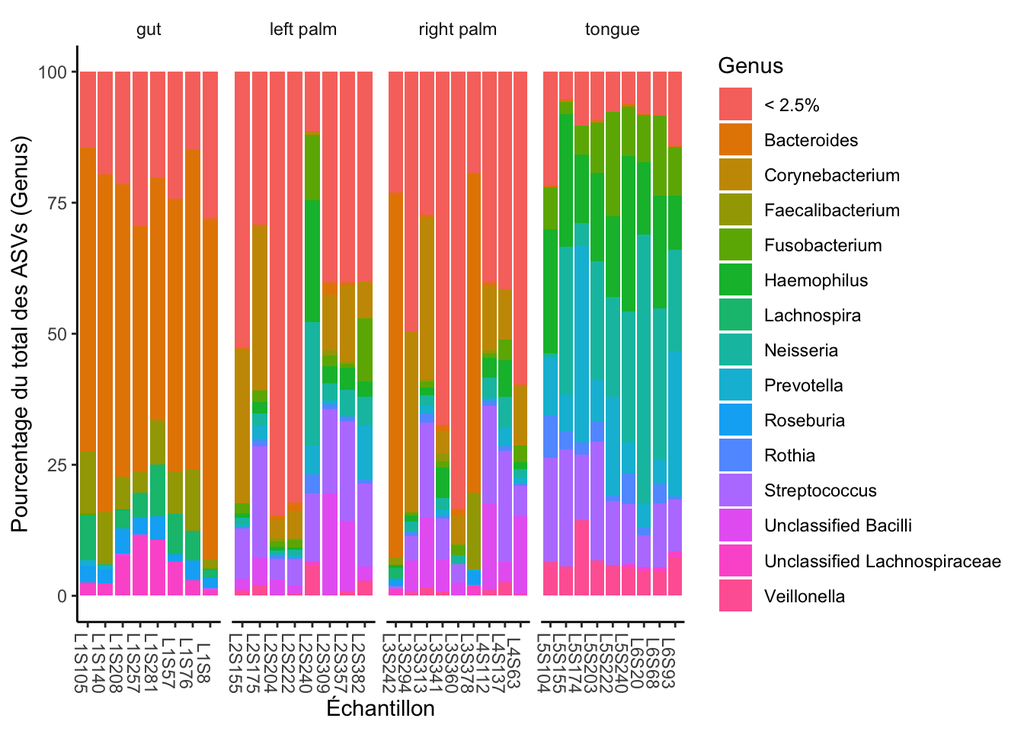

```r
ggplot(ps.melt_sum, aes(x = Sample, y = Abundance, fill = Genus)) +
  geom_bar(stat = "identity", aes(fill=Genus)) +
  labs(x="Échantillon", y="Pourcentage du total des ASVs (Genus)") +
  facet_wrap(~body.site, scales= "free_x", nrow=1) +
  theme_classic() +
  theme(legend.position = "right",
        strip.background = element_blank(),
        axis.text.x.bottom = element_text(angle = -90))
```

# QUESTION 13 : Ici, nous pouvons voir l’abondance relative de chaque GENRE microbien. En comparaison avec ce que nous avons vu pour les phyla microbiens, comment la variation des communautés microbiennes des sites corporels diffère-t-elle au niveau des genres ? En général, quels sites corporels sont similaires et lesquels sont différents ?